# Modélisation avancée

- Choix de modèles pré-entrainés
- Optimisation : EarlyStopping , Keras Tuner

Classification:

- Binaire: Sain/Malade
- Multiclasse : 4 classes : Normal / Viral_Pneumonia / Lung_Opacity / COVID
- 3 classes : Hors Lung Opacity
- COVID / Pas COVID

# Les modèles sélectionnés

- VGG16
- VGG19
- ResNet50
- EfficientNetB0

Nous avons sélectionnés ces modèles pour les raisons suivantes:

- Utilisation des mêmes dimensions des images
- Dimensions nécessaires sont inférieures aux dimensions des images brutes Inconvénient:
- Besoin de conserver les images en RGB, contrairement à notre approche initiale de remise en Niveau de Gris de toutes les images

# Les modèles sélectionnés par classification:

- Binaire Sain / Malade: VGG16, VGG19
- Multiclasse : ResNet50 et EfficientNetB0

## Les données

- 600 images par classe sélectionnés aléatoirement
- Dimensions par défaut des modèles : 224x224x3 (RGB)

# Les techniques d'optimisation utilisées

EfficientNetB0:

- EarlyStopping : EfficientNetB0
- Keras Tuning RandomSearch : EfficientNetB0 / VGG16 et VGG19
- Dégel de couches pré-entrainées : EfficientNetB0 / VGG16 et VGG19

## Les données

- 600 images par classe sélectionnés aléatoirement
- Dimensions standards des modèles

## Métriques

- F1 Score
- Recall
- Restitution: Matrice de confusion et Rapport de classification

## Interprétabilité:

GradCAM

# Cas 1 - Binaire : Sain / Malade

1. Taille = 28
2. Images = 600 images par classe
- Sain = Normal
- Malade = 1/3 COVID, 1/3 Viral Pneumonia / 1/3 Lung Opacity

```python
import matplotlib.pyplot as plt
from PIL import Image

def load_and_display_image(image_path):
    img = Image.open(image_path)
    plt.imshow(img)
    plt.axis('off')  # Cela enlève les axes
    plt.show()
```

# VGG 16

## Courbe d'entrainement

### VGG16 Sain/Malade - Précision

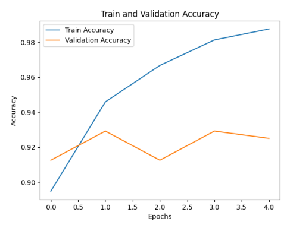

```python
load_and_display_image("./metriques_courbes/vgg16_entrainement_accuracy.png")
```

### VGG16 Sain/Malade - Perte

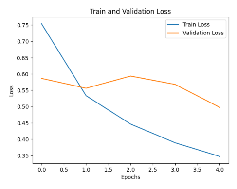

```python
load_and_display_image("./metriques_courbes/vgg16_entrainement_loss.png")
```

### VGG16 Sain/Malade - Matrice de confusion

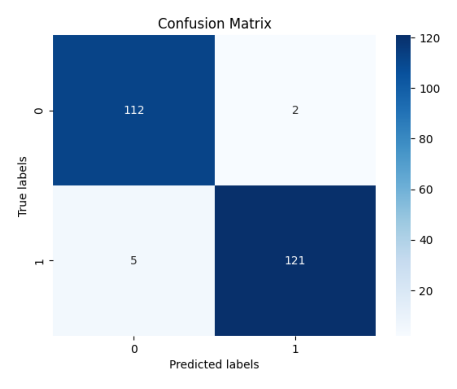

```python
load_and_display_image("./metriques_courbes/VGG16_confusion_matrix.png")
```

### VGG16 Sain/Malade - Gradcam

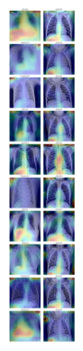

```python
load_and_display_image("./interpretabilite_gradcam/VGG16_GradCam.png")
```

## VGG19

### VGG19 Sain/Malade - Précision

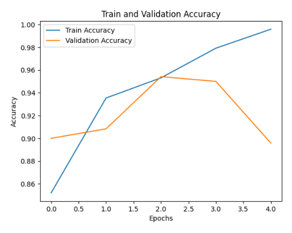

```python
load_and_display_image("./metriques_courbes/vgg19_entrainement_accuracy.png")
```

### VGG19 Sain/Malade - Perte

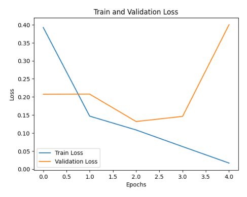

```python
load_and_display_image("./metriques_courbes/vgg19_entrainement_loss.png")
```

### VGG19 Sain/Malade - Matrice de confusion

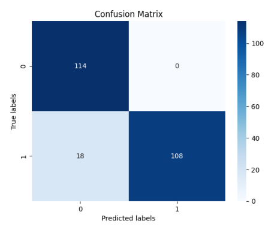

```python
load_and_display_image("./metriques_courbes/VGG19_confusion_matrix.png")
```

### VGG19 Sain/Malade - Gradcam

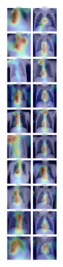

```python
load_and_display_image("./interpretabilite_gradcam/VGG19_GradCam.png")
```

# Cas 2 - Multiclasse

## EfficientNet B0

## Courbe d'entrainement

### EfficientNetB0 Multiclasse - Précision

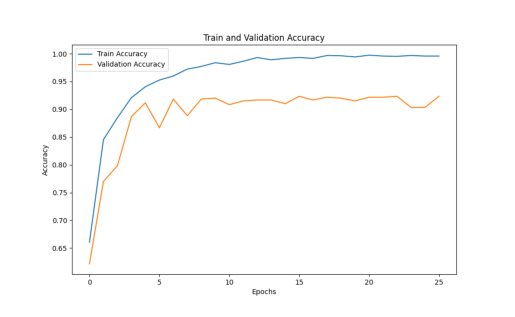

```python
load_and_display_image("./metriques_courbes/EfficientNetB0_MC_750_history_accuracy.png")
```

### EfficientNetB0 Multiclasse - Perte

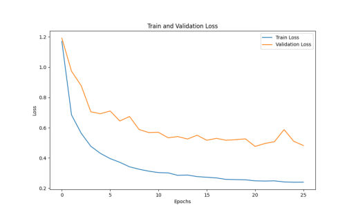

```python
load_and_display_image("./metriques_courbes/EfficientNetB0_MC_750_history_loss.png")
```

### EfficientNetB0 Multiclasse - Matrice de confusion

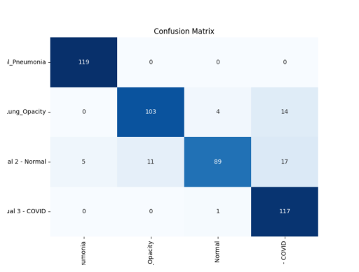

```python
load_and_display_image("./metriques_courbes/EfficientNetB0_MC_750_confusion_matrix.png")
```

### EfficientNetB0 Multiclasse - Gradcam

```python
### Non implémenté
```

# ResNet 50

## Courbe d'entrainement

### ResNet 50 Multiclasse - Précision et perte

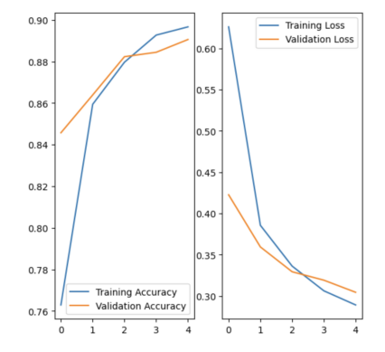

```python
load_and_display_image("./metriques_courbes/ResNet50_train_validation_accuracy_loss.png")
```

# Cas 3 - Binaire Covid/Pas COVID

## EfficientNet B0

## Courbe d'entrainement

### EfficientNetB0 COVID / PAS COVID - Précision

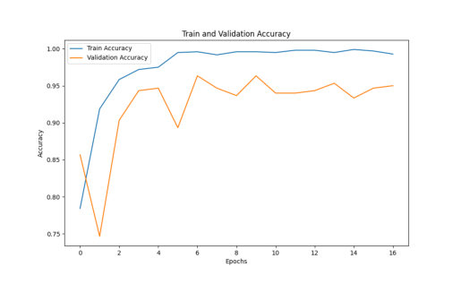

```python
load_and_display_image("./metriques_courbes/EfficientNetB0_CV_750_history_accuracy.png")
```

### EfficientNetB0 COVID / PAS COVID - Perte

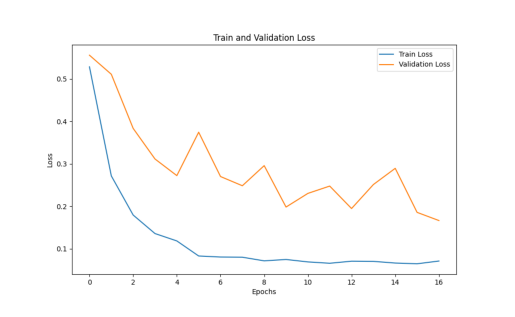

```python
load_and_display_image("./metriques_courbes/EfficientNetB0_CV_750_history_loss.png")
```

### EfficientNetB0 COVID / PAS COVID - Matrice de confusion

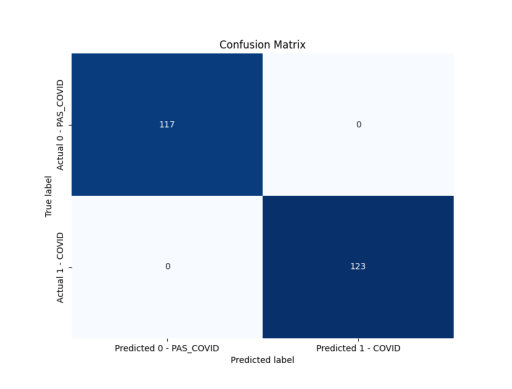

```python
load_and_display_image("./metriques_courbes/EfficientNetB0_CV_750_confusion_matrix.png")
```

# Cas 4 - 3 classes : (Hors Lung Opacity)

## EfficientNet B0

## Courbe d'entrainement

### EfficientNetB0 3 classes - Précision

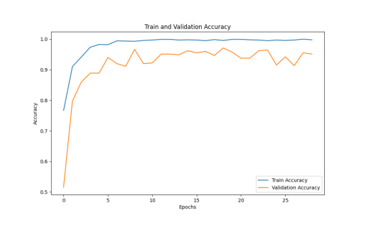

```python
load_and_display_image("./metriques_courbes/EfficientNetB0_3C_750_history_accuracy.png")
```

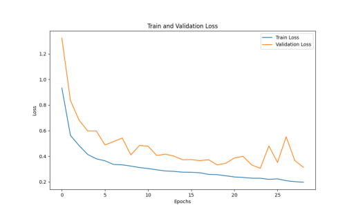

```python
load_and_display_image("./metriques_courbes/EfficientNetB0_3C_750_history_loss.png")
```

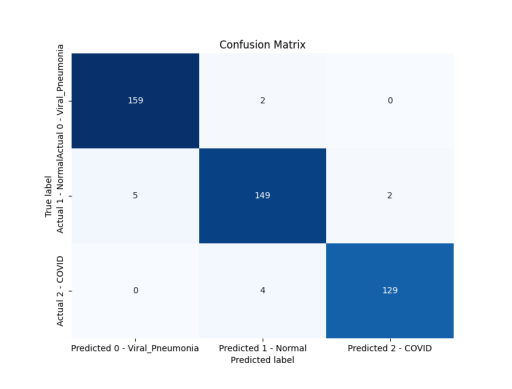

```python
load_and_display_image("./metriques_courbes/EfficientNetB0_3C_750_confusion_matrix.png")
```

# ResNet50

## Courbe d'entrainement

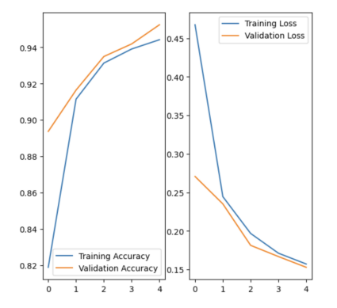

```python
load_and_display_image("./metriques_courbes/ResNet50_3C_train_validation_accuracy_loss.png")
```